# How to forecast sales with advertising spend in R

```r
# Install pacman if needed
if (!require("pacman")) install.packages("pacman")

# load packages
pacman::p_load(pacman,
  tidyverse, openxlsx, forecast, psych)
```

```r
#Import dataset
diet <- read.xlsx("~/Documents/GitHub/Forecasting-in-R/Forecasting-in-R/datasets/Addata.xlsx", skipEmptyRows = TRUE)
```

## Date exploration

```r
#Check results
str(diet)
```

```
'data.frame':   36 obs. of  3 variables:
 $ Month      : num  1 2 3 4 5 6 7 8 9 10 ...
 $ Sales      : num  12 20.5 21 15.5 15.3 23.5 24.5 21.3 23.5 28 ...
 $ Advertising: num  15 16 18 27 21 49 21 22 28 36 ...
```

Let’s get a sense of the data so we will do some visualizations of our sales data.

```r
#Use describe function from psych package. It gives a good overview of the dataset variables.
describe(diet)
```

|  | vars | n | mean | sd | median | trimmed | mad | min | max | range | skew | kurtosis | se |
| --- | --- | --- | --- | --- | --- | --- | --- | --- | --- | --- | --- | --- | --- |
| Month | 1 | 36 | 18.50 | 10.54 | 18.50 | 18.50 | 13.34 | 1 | 36.0 | 35.0 | 0.00 | -1.30 | 1.76 |
| Sales | 2 | 36 | 24.25 | 6.18 | 24.25 | 24.17 | 6.38 | 12 | 36.5 | 24.5 | 0.04 | -0.82 | 1.03 |
| Advertising | 3 | 36 | 28.53 | 18.78 | 23.00 | 27.60 | 19.27 | 1 | 65.0 | 64.0 | 0.45 | -0.90 | 3.13 |

Average monthly sales is 24k with a standard deviation of 6 while advertising spend average around 29k with a very large deviation of 19k.

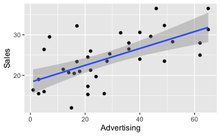

```r
#Plot Sales by Advertising
ggplot(diet, aes(x=Advertising, y=Sales)) + geom_point() + geom_smooth(method = 'lm')
```

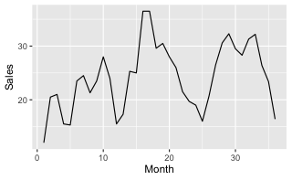

```r
#Plot sales over 36 months
ggplot(diet, aes(x=Month, y = Sales)) + geom_line()
```

First, a scatterplot of sales and advertising. Sales are generally high when advertising spend is high which is perhaps not a big surprise, but this is not necessarily always the case. There seems to be wide variability between sales and advertising and the points all over the place.

If we look at our sales data over time, we can see a lot of peaks and dips. There are definitely some dips around months 12, 24 and now 36 which suggests that sales are down around the Christmas holidays, but picks back up rather quickly.

## Dynamic Regression Modeling

```r
#Convert dataframe to time series object using the ts() function
diet_ts <- ts(data = diet[,c(2,3)])


#Check results of transformation
diet_ts
```

```
Time Series:
Start = 1
End = 36
Frequency = 1
   Sales Advertising
 1  12.0          15
 2  20.5          16
 3  21.0          18
 4  15.5          27
 5  15.3          21
 6  23.5          49
 7  24.5          21
 8  21.3          22
 9  23.5          28
10  28.0          36
```

[output cut: 26 more lines]

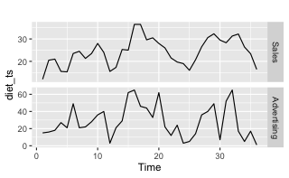

```r
# Time plot of both variables
autoplot(diet_ts, facets = TRUE)
```

We fit our model with auto.arima function from the forecast package.

```r
# Fit ARIMA model
fit <- auto.arima(diet_ts[, "Sales"], xreg = diet_ts[, "Advertising"], stationary = TRUE)

# Check model fit
fit
```

```
Series: diet_ts[, "Sales"]
Regression with ARIMA(1,0,0) errors

Coefficients:
         ar1  intercept    xreg
      0.6412    20.8737  0.0926
s.e.  0.1559     2.0842  0.0426

sigma^2 estimated as 18.48:  log likelihood=-102.28
AIC=212.55   AICc=213.84   BIC=218.89
```

The auto.arima function has fit a linear regression model to the advertising variable and an an ARIMA model to the time series (month) variable. ARIMA (1,0,0)

```r
#What is the increase in sales for each unit increase in advertising?
sales_increase <- coefficients(fit)[3]
```

Interpretation of sales increase: For every $1,000 (the unit of ad spend is in thousands USD) increase in advertising spend, the unit sales increase by 0.09.

```
    Ljung-Box test

data:  Residuals from Regression with ARIMA(1,0,0) errors
Q* = 4.5652, df = 4, p-value = 0.3349

Model df: 3.   Total lags used: 7
```

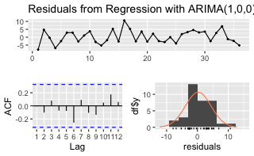

```r
#Check Residuals
checkresiduals(fit)
```

P-value is larger than 0.05 so the residuals are white noise. The residuals look nearly normally distributed.

## Forecasting for the next quarter

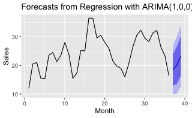

```r
#We need to provide forecast with the future value of our predictor which is Advertising. So here, we will spend 5 in month 1, 12 in month 2 and 40 in month 3.

#Create a vector to hold advertising spend
adv_spend <- c(5, 12, 40)

#Let's build the forecast
diet_fc <- forecast(fit, xreg = adv_spend)

# Plot forecast
autoplot(diet_fc) + xlab("Month") + ylab("Sales")
```

```r
#Print forecast with confidence intervals
diet_fc
```

|  | Point Forecast | Lo 80 | Hi 80 | Lo 95 | Hi 95 |
| --- | --- | --- | --- | --- | --- |
| 37 | 18.40883 | 12.90030 | 23.91737 | 9.984257 | 26.83341 |
| 38 | 20.10783 | 13.56408 | 26.65158 | 10.100031 | 30.11563 |
| 39 | 23.37542 | 16.45077 | 30.30007 | 12.785082 | 33.96576 |

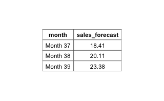

## Forecasts using a Train/Test split

```r
#We will use the first 33 months to train
training <- window(diet_ts, end = 33)
test <- window(diet_ts, start = 34)


# Fit ARIMA model
fit_02 <- auto.arima(training[, "Sales"], xreg = training[, "Advertising"], stationary = TRUE)

# Check model fit
fit_02
```

```
Series: training[, "Sales"]
Regression with ARIMA(1,0,0) errors

Coefficients:
         ar1  intercept    xreg
      0.6940    21.9815  0.0762
s.e.  0.1531     2.5000  0.0416

sigma^2 estimated as 18.96:  log likelihood=-94.13
AIC=196.26   AICc=197.69   BIC=202.24
```

```
    Ljung-Box test

data:  Residuals from Regression with ARIMA(1,0,0) errors
Q* = 5.2197, df = 4, p-value = 0.2655

Model df: 3.   Total lags used: 7
```

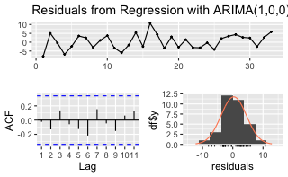

```r
#Check residuals on our training set
checkresiduals(fit_02)
```

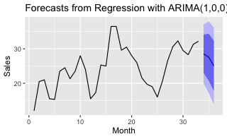

```r
#Forecast sales on the test set
diet_fc_02 <- forecast(fit_02, xreg = test[,2])

# Plot test set forecast
autoplot(diet_fc_02) + xlab("Month") + ylab("Sales")
```

At first glance, our forecasts look pretty good although the confidence intervals are a bit wide.

```r
#Print forecast
diet_fc_02
```

|  | Point Forecast | Lo 80 | Hi 80 | Lo 95 | Hi 95 |
| --- | --- | --- | --- | --- | --- |
| 34 | 28.55478 | 22.97453 | 34.13504 | 20.02052 | 37.08904 |
| 35 | 27.57436 | 20.78203 | 34.36670 | 17.18638 | 37.96234 |
| 36 | 25.03986 | 17.73520 | 32.34452 | 13.86835 | 36.21138 |

## How do you know if your forecasts are any good?

```r
#Evaluate accuracy
accuracy(diet_fc_02, test[,1])
```

```
                     ME     RMSE      MAE        MPE
Training set  0.3283182 4.151658 3.573361  -2.323035
Test set     -4.9896683 5.677899 4.989668 -26.227763
                 MAPE      MASE        ACF1 Theil's U
Training set 16.03978 0.9995417 -0.02422498        NA
Test set     26.22776 1.3957114 -0.03018011  1.255173
```

```r
#Combine test data and the forecasts into a tibble dataframe
explanatory_data <- as_tibble(cbind(test, diet_fc_02))

#Make sure to use the back ticks when referencing the column names from the forecast model
explanatory_data <- explanatory_data %>%
  mutate(errors = test.Sales - `diet_fc_02.Point Forecast`,
         squared_error = (test.Sales - `diet_fc_02.Point Forecast`)^2)

#View results - Select only the relevant columns
explanatory_data %>%
  select(test.Sales, `diet_fc_02.Point Forecast`, errors, squared_error)
```

| test.Sales | diet_fc_02.Point Forecast | errors | squared_error |
| --- | --- | --- | --- |
| 26.4 | 28.55478 | -2.154780 | 4.643078 |
| 23.4 | 27.57436 | -4.174362 | 17.425301 |
| 16.4 | 25.03986 | -8.639862 | 74.647220 |

```r
#Calculate standard error across all forecasts
(standard_error <- sd(explanatory_data$errors, na.rm = TRUE))
```

```
[1] 3.318526
```

```r
#Calculate sse across all forecasts
(sse <- sum(explanatory_data$squared_error, na.rm = TRUE))
```

```
[1] 96.7156
```

All of our forecasts were above actual sales (hence the negative errors).

Our forecast error was the lowest for month 34, slightly higher for month 35 and the absolute worst forecast was for month 36. There does appear to be an interaction between advertising and sales.

```r
#Computing the mean absolute percentage error (MAPE)
mean(abs((explanatory_data$test.Sales-explanatory_data$`diet_fc_02.Point Forecast`)/explanatory_data$test.Sales)) * 100
```

```
[1] 26.22776
```

Forecasts are off by on the test set 26% which is rather high and was much lower on the training set. This gives us the same result as the accuracy function from above, but there may be times you may need to manually calculate MAPE.